# Assignment Wind Power

### 3. Simple models:

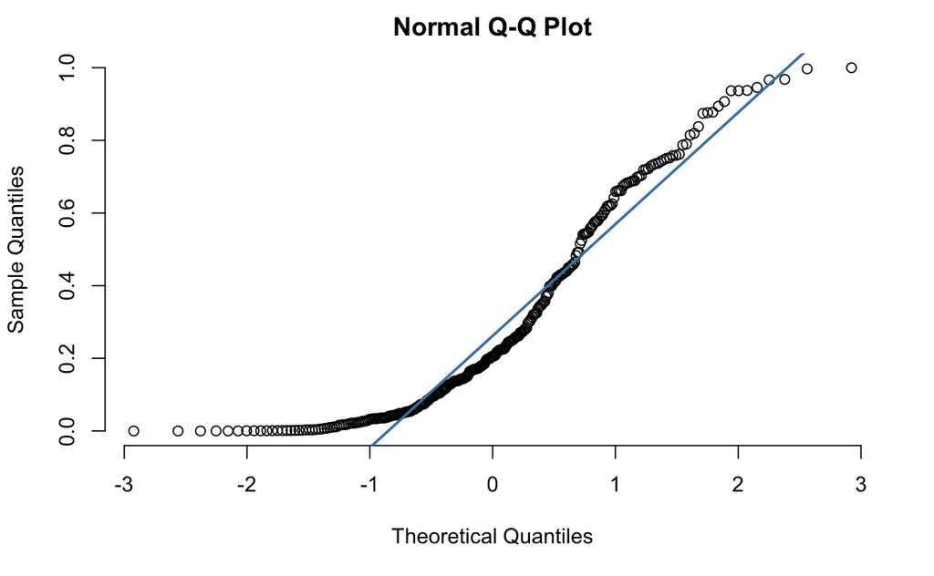

```r
data$pow.obs.norm.log<-log(data$pow.obs.norm)

qqnorm(data$pow.obs.norm, pch = 1, frame = FALSE)
qqline(data$pow.obs.norm, col = "steelblue", lwd = 2)
```

The curvature of the qq-plot indicates that a beta distribution might fit the data well. **http://onlinestatbook.com/2/advanced_graphs/q-q_plots.html

#### Fitting a beta distribution to the data.

The likelihood function for the wind data, can be defined as a sum of the log density functions
$$l(\theta)=\sum_{i=1}^{n}log(p_{\theta}(x_{i}))$$

where $p_{\theta}$ in this case is the beta density function given as:
$$f(x) = \frac{(x-a)^{p-1}(b-x)^{q-1}}{B(p,q) (b-a)^{p+q-1}}
\hspace{.3in} a \le x \le b; p, q > 0$$

where p and q are the shape parameters, a and b are the lower and upper bounds, respectively, of the distribution, and B(p,q) is the beta function. The beta function has the formula
$$B(\alpha,\beta) = \int_{0}^{1} {t^{\alpha-1}(1-t)^{\beta-1}dt}$$
The likelihood function can easily be implemented in R:

```r
Beta.likelihood=function(shape1, shape2){ -sum(dbeta(x=data$pow.obs.norm,shape1=shape1, shape2=shape2, log=TRUE))}
```

Now the optimal value of the two shape parameters must be found. This can be done using profile likelihood, the profile likelihood is defined as: Let $(\theta, \delta)$ be the full parameter and $\theta$ the parameter of interest. Given the joint likelihood $L(\theta, \delta)$ the profile likelihood of $\theta$ is
$$L(\theta)=max_{\delta}L(\theta, \delta)$$
Where the maximation is performed at fixed value of $\theta$ .

```r
#Profile likelihood for shape1
shape1=seq(0.35, 0.68,by=0.001)
shape2=seq(0.8, 1.6,by=0.01)


lp.shape1= function(shape1){
  ## Function for inner optimization:
  fun.tmp<- function(shape1, shape2){
    Beta.likelihood(shape1,shape2)
  }
  # Find the profile likelihood
  optimise(fun.tmp,c(0.1,10), shape1=shape1)$objective
}

(opt.shape1=optimise(lp.shape1, c(0.1,10))$minimum)
```

```
[1] 0.5051217
```

```r
#Profile likelihood for shape2

lp.shape2= function(shape2){
  ## Function for inner optimization:
  fun.tmp<- function(shape1, shape2){
    Beta.likelihood(shape1,shape2)
  }
  # Find the profile likelihood
  optimise(fun.tmp,c(0.1,10), shape2=shape2)$objective
}

(opt.shape2=optimise(lp.shape2, c(0.1,10))$minimum)
```

```
[1] 1.147125
```

This means, that the MLE for the two shape parameters are $shape1=0.5051217$ and $shape2=1.147125$.

```r
# Profile likelihoods:
lp.shape1.plot= sapply(shape1, lp.shape1)
lp.shape2.plot= sapply(shape2, lp.shape2)

par(mfrow=c(2,1), mar=c(3.3,3.3,1,1),mgp=c(2,0.7,0))
plot(shape1,exp(-lp.shape1.plot), type="l", xlab="Profile Likelihood Shape 1")
lines(c(-2,10),exp(-qchisq(0.95,df=1)/2)*c(1,1),col=2)
```

[figure not shown]

```r
plot(shape2,exp(-lp.shape2.plot), type="l", xlab="Profile Likelihood Shape 2")
lines(c(-2,10),exp(-qchisq(0.95,df=1)/2)*c(1,1),col=2)
```

[output not shown]

What next?